# TP Nº 8: Análisis de Regresión y Correlación Lineal

## Ejercicio 1

Los siguientes datos representan la cantidad de agua aplicada (cm<sup>3</sup>) y el rendimiento de una especie forrajera (tn MS ha<sup>-1</sup>), en un establecimiento de la provincia de Santa Fe.

```
 agua   MS
   12 5.27
   18 5.68
   24 6.25
   30 7.53
   36 8.02
```

`agua_forrajera.xlsx`

1. Hacer un diagrama de dispersión ¿como es la relación entre las variables?
2. Hallar la recta de regresión del rendimiento en función del agua. Representar gráficamente. Interpretar los parámetros.
3. ¿Es estadísticamente significativo el coeficiente de regresión?
4. Interpretar la bondad de ajuste del modelo.
5. Estimar los intervalos de confianza de los parámetros del modelo.
6. Predecir cual será el rendimiento del forraje si se aplican 20 cm<sup>3</sup>.

**Respuesta**

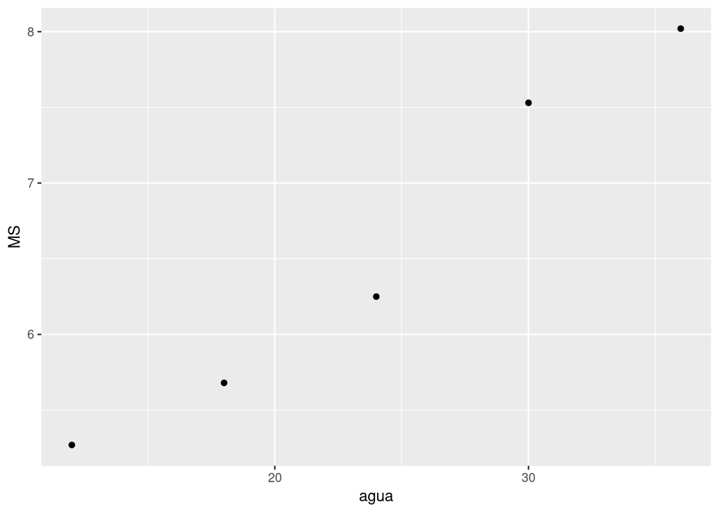

```r
# Grafico de dispersión o Scatterplot
library(ggplot2)
ggplot(x, aes(agua, MS)) +
  geom_point()
```

```r
# Modelo lineal: ajuste
mod <- lm(MS ~ agua, x)
mod
```

```
Call:
lm(formula = MS ~ agua, data = x)

Coefficients:
(Intercept)         agua
     3.6100       0.1225
```

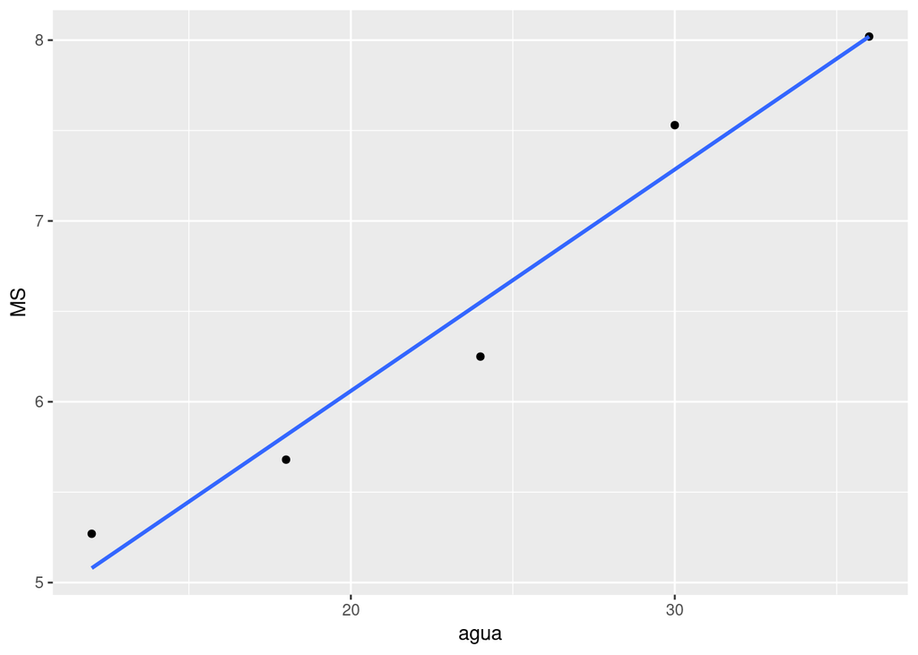

```r
# Agregar linea al grafico de dispersión
ggplot(x, aes(agua, MS)) +
  geom_point() +
  geom_smooth(method = lm, # Recta de regresión
              se = FALSE)  # Oculta intervalo de confianza
```

El modelo es: $MS = 3.61 +0.1225*agua$

3. Significancia de la regresión

```r
summary(mod)
```

```
Call:
lm(formula = MS ~ agua, data = x)

Residuals:
         1          2          3          4          5
 1.900e-01 -1.350e-01 -3.000e-01  2.450e-01 -8.257e-16

Coefficients:
            Estimate Std. Error t value Pr(>|t|)
(Intercept)  3.61000    0.35016  10.310  0.00195 **
agua         0.12250    0.01376   8.906  0.00299 **
---
Signif. codes:  0 '***' 0.001 '**' 0.01 '*' 0.05 '.' 0.1 ' ' 1

Residual standard error: 0.261 on 3 degrees of freedom
Multiple R-squared:  0.9636,    Adjusted R-squared:  0.9514
F-statistic: 79.31 on 1 and 3 DF,  p-value: 0.002986
```

4. Bondad de ajuste o Coeficiente de Determinación

```r
# Coeficiente correlación
r <- with(x, cor(agua, MS))

# R-cuadrado
r^2
```

```
[1] 0.9635519
```

```r
# O de la tabla resumen
summary(mod)
```

```
Call:
lm(formula = MS ~ agua, data = x)

Residuals:
         1          2          3          4          5
 1.900e-01 -1.350e-01 -3.000e-01  2.450e-01 -8.257e-16

Coefficients:
            Estimate Std. Error t value Pr(>|t|)
(Intercept)  3.61000    0.35016  10.310  0.00195 **
agua         0.12250    0.01376   8.906  0.00299 **
---
Signif. codes:  0 '***' 0.001 '**' 0.01 '*' 0.05 '.' 0.1 ' ' 1

Residual standard error: 0.261 on 3 degrees of freedom
Multiple R-squared:  0.9636,    Adjusted R-squared:  0.9514
F-statistic: 79.31 on 1 and 3 DF,  p-value: 0.002986
```

5. Intervalos de confianza

```r
confint(mod)
```

```
                 2.5 %   97.5 %
(Intercept) 2.49564381 4.724356
agua        0.07872395 0.166276
```

6. Predicción

```r
# con la función "predict"
MS20 <- predict(mod, newdata = list(agua = 20))
MS20
```

```
   1
6.06
```

```r
# o manualmente
3.61+0.1225*20
```

```
[1] 6.06
```

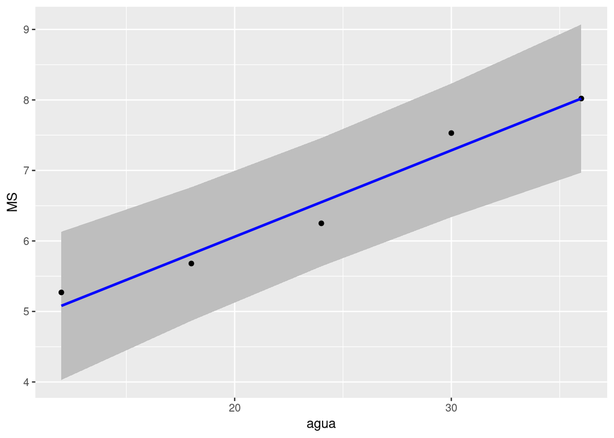

```r
# Graficamente
x2 = cbind(x, predict(mod, interval = "prediction")) # crea columnas de LI, LS y valor ajustado para cada valor de X
ggplot(x2, aes(x = agua)) +
geom_ribbon(aes(ymin = lwr, ymax = upr), fill = "gray") + # sombreado del intervalo de predicción
geom_point(aes(y = MS)) + # columna que representa los valores del eje y
geom_line(aes(y = fit), colour = "blue", size = 1) #línea de regresión
```

## Ejercicio 2

A continuación se detallan los datos de una muestra de 12 explotaciones agrícolas donde se registra el tamaño de las mismas y el área sembrada con trigo:

```
 sup_total sup_trigo
       147        56
       125        42
       160        72
       118        36
       149        63
       128        47
       150        55
       145        49
       115        38
       140        42
       152        68
       152        60
```

`area_trigo.xlsx`

1. Explorar gráficamente la relación entre la superficie total de la explotación y la superficie destinada al cultivo de trigo.
2. Calcular e interpretar el coeficiente de correlación.
3. Determinar si la correlación observada es estadísticamente significatvia 5%.

**Respuesta**

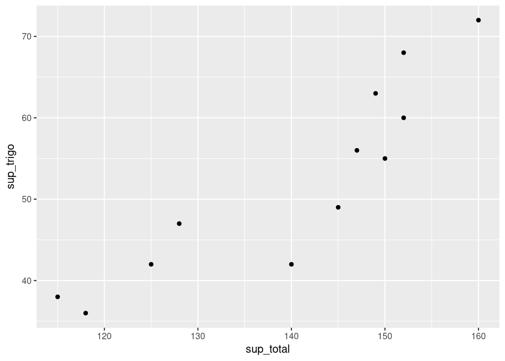

```r
# Grafico de dispersióo Scatterplot
library(ggplot2)
ggplot(x, aes(sup_total, sup_trigo)) +
  geom_point()
```

```r
with(x, cor(sup_total, sup_trigo))
```

```
[1] 0.8989093
```

3. $$H_0: \rho = 0$$
   $$H_1: \rho \ne 0$$

```r
with(x, cor.test(sup_total, sup_trigo))
```

```
    Pearson's product-moment correlation

data:  sup_total and sup_trigo
t = 6.488, df = 10, p-value = 7.002e-05
alternative hypothesis: true correlation is not equal to 0
95 percent confidence interval:
 0.6713448 0.9715846
sample estimates:
      cor
0.8989093
```

*Se rechaza $H_0$*

## Ejercicio 3

Los siguientes datos proceden de un estudio de pérdida de agua en el coleóptero de la harina (*Tribolium confusum*). Se pesaron 9 lotes de 25 coleópteros cada uno, se guardaron a diferente humedad relativa y se pesaron nuevamente a los 6 días. Se calculó la pérdida de peso (mg) para cada lote:

```
   HR perdida
  0.0    8.98
 12.0    8.14
 29.5    6.67
 43.0    6.08
 53.0    5.90
 62.5    5.83
 75.5    4.68
 85.0    4.20
 93.0    3.72
```

`coleoptero.xlsx`

1. Hace un gráfico de dispersión. ¿como es la relación entre la humedad relativa y la pérdida de peso?
2. Obtener la recta de regresión lineal.
3. Determinar con un nivel de significancia del 5% si la pendiente de la recta es diferente de 0. ¿Qué representa este valor?
4. Estimar con un 95% de confianza los límites del intervalo que contiene a la verdadera tasa de peridad de peso.
5. Estimar con un 95% de confianza los límites del intervalo que contiene a la verdadera peridad de peso cuando la humedad relativa es 0%.
6. ¿Que propoción de variabilidad de la perdida de peso no es explicada por el modelo?

**Respuesta**

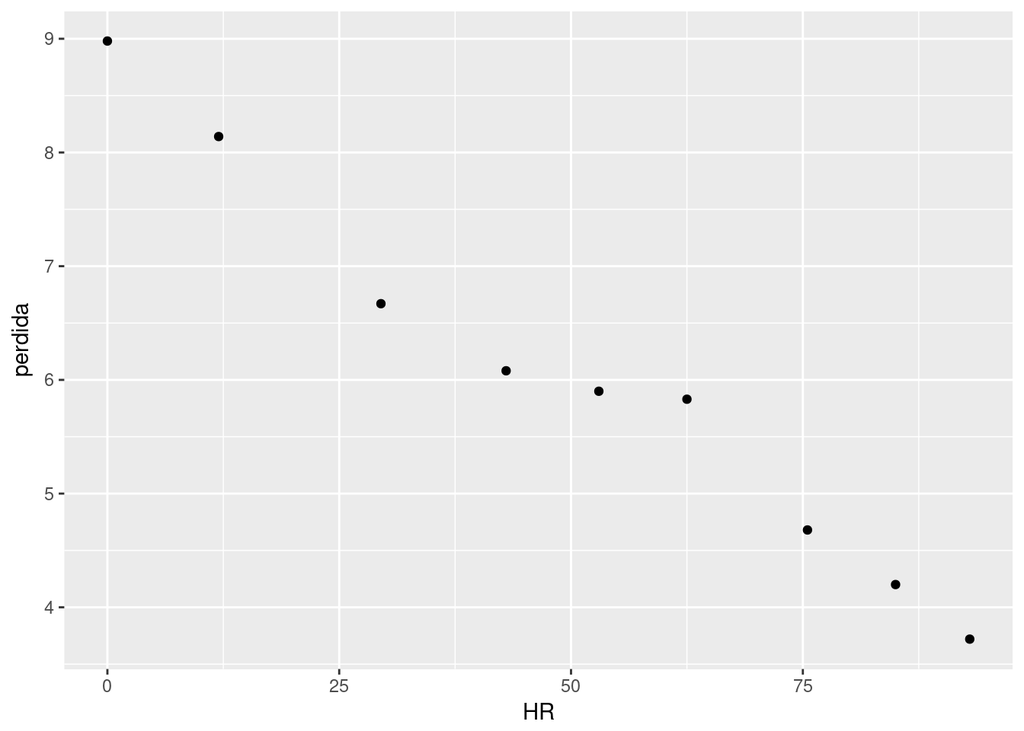

```r
library(ggplot2)
ggplot(x, aes(HR, perdida)) +
  geom_point()
```

```r
mod<- lm(HR~ perdida, x)
mod
```

```
Call:
lm(formula = HR ~ perdida, data = x)

Coefficients:
(Intercept)      perdida
     160.65       -18.31
```

_ El modelo queda: Y = 160.65 - 18.31 X_

3. $$H_0: \beta_1 = 0$$
   $$H_1: \beta_1 \ne 0$$

```r
summary(mod)
```

```
Call:
lm(formula = HR ~ perdida, data = x)

Residuals:
    Min      1Q  Median      3Q     Max
-9.0284  0.3733  0.4586  1.2472  8.5916

Coefficients:
            Estimate Std. Error t value Pr(>|t|)
(Intercept)  160.653      6.991   22.98 7.49e-08 ***
perdida      -18.309      1.120  -16.35 7.82e-07 ***
---
Signif. codes:  0 '***' 0.001 '**' 0.01 '*' 0.05 '.' 0.1 ' ' 1

Residual standard error: 5.502 on 7 degrees of freedom
Multiple R-squared:  0.9745,    Adjusted R-squared:  0.9708
F-statistic: 267.2 on 1 and 7 DF,  p-value: 7.816e-07
```

*Existe evidencia significativa para rechazar $H_0$ (P<0.0001), la regresión es significativa*

```r
confint(mod)
```

```
                2.5 %    97.5 %
(Intercept) 144.12241 177.18281
perdida     -20.95818 -15.66077
```

```r
1 - 0.9745
```

```
[1] 0.0255
```

## Ejercicio 4

Se realizó un experimento para determinar la relación entre la cantidad de P inorgánico en el suelo (ppm) al inicio del cultivo de maiz y la cantidad de P que es recuperada por la planta (en ppm) a los 30 días. Para ello se prepararon macetas con distintas concentraciones de P inicial a las cuales se les sembró el mismo híbrido de maiz y luego de 30 días se determinó el contenido de P en planta. Los resultados fueron:

```
 P_suelo P_planta
     0.4       64
     3.1       71
     4.7       54
     9.4       81
    11.6       98
    10.9       76
    23.1       76
    23.1       95
    29.9       99
```

`P_maiz.xlsx`

1. Graficar la relación entre `P_suelo` y `P_planta`.
2. Asumiendo que el valor de P_suelo se mide sin error, estimar los parámetros de un modelo lineal que relacione ambas variables.
3. Estimar con un 95% de confianza el intervalo que contenga el aumento del `P_planta` por cada unidad de `P_suelo`.
4. Estimar el contenido de `P_planta` si en el suelo hay 20 ppm de fósforo.

**Respuesta**

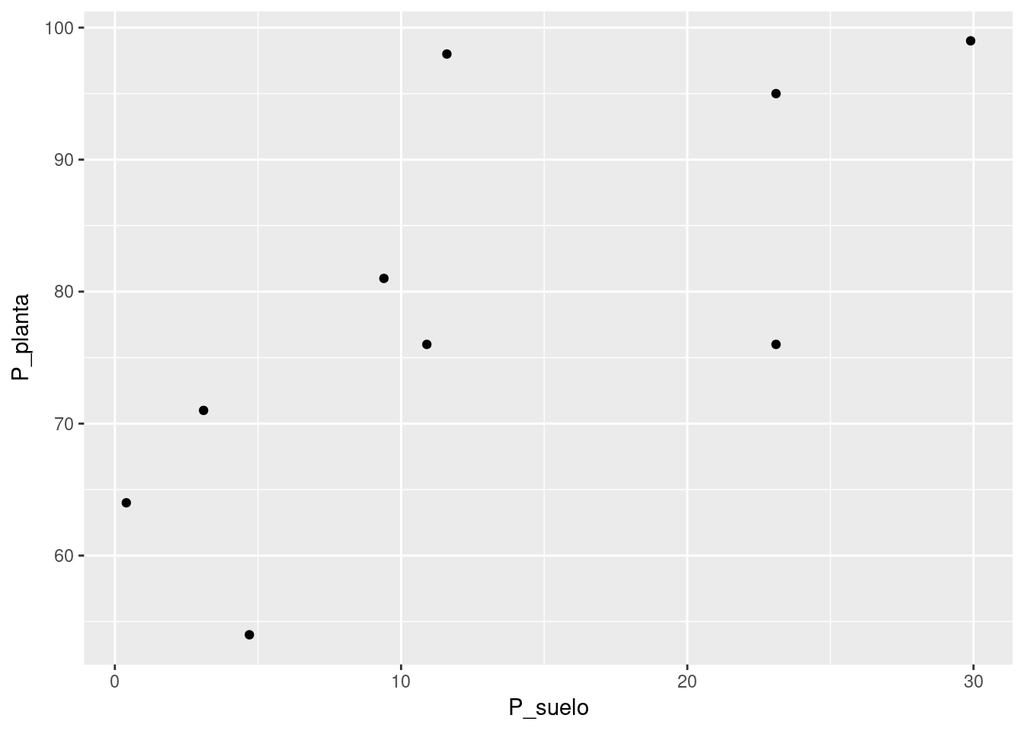

```r
library(ggplot2)
ggplot(x, aes(P_suelo, P_planta)) +
  geom_point()
```

```r
mod<- lm(P_planta~ P_suelo, x)
mod
```

```
Call:
lm(formula = P_planta ~ P_suelo, data = x)

Coefficients:
(Intercept)      P_suelo
      65.13         1.10
```

```r
confint(mod)
```

```
                 2.5 %    97.5 %
(Intercept) 49.8350608 80.434498
P_suelo      0.1498156  2.049616
```

IC $\beta_1$ 95% = 0.1498 ; 2.049

```r
predict(mod, newdata = list(P_suelo = 20))
```

```
      1
87.1291
```

## Ejercicio 5

Los siguientes datos representan el rendimiento en toneladas de forraje y la lluvia caída en mm, durante los meses de julio y agosto en 10 establecimientos elegidos al azar, en una determinada región.

```
 rend lluvia
    2      3
    1      6
    5      9
    3     12
    6     15
    4     18
    8     21
    9     24
   10     27
    7     30
```

`lluvia_forraje.xlsx`

1. Grafique la relación entre ambas variables.
2. ¿Se podría postular que la lluvia caida durante los meses de julio y agosto tiene una relación lineal con la producción de forraje?
3. Con un 95% de confianza, ¿entre que valores se encuentra la correlación entre tasa de producción de pasto por milímetro de lluvia caido?
4. Si la lluvia caída fue de 20 mm, predecir cuál será el rendimiento de forraje.

**Respuesta**

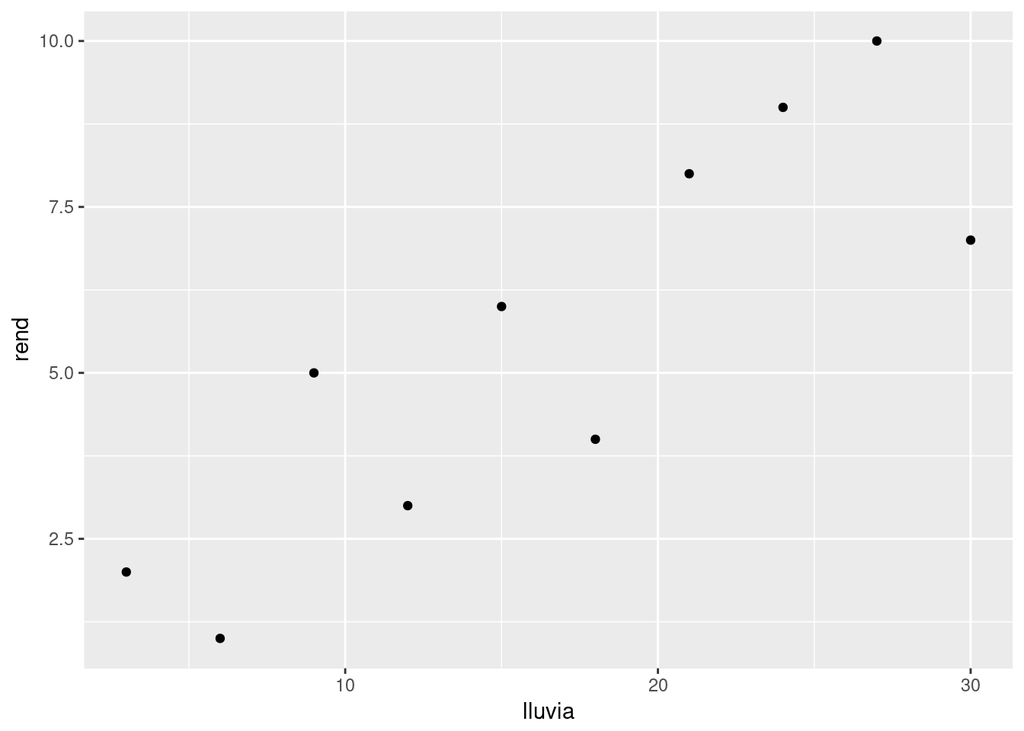

```r
library(ggplot2)
ggplot(x, aes(lluvia, rend)) +
  geom_point()
```

2. $$H_0: \rho = 0$$
   $$H_1: \rho \ne 0$$

```r
with(x, cor.test(lluvia,rend))
```

```
    Pearson's product-moment correlation

data:  lluvia and rend
t = 4.6537, df = 8, p-value = 0.001637
alternative hypothesis: true correlation is not equal to 0
95 percent confidence interval:
 0.4868847 0.9649734
sample estimates:
      cor
0.8545455
```

*Se rechaza $H_0$ (P=0.001), la regresión es significativa%*

3. IC 95% = 0.4868 ; 0.9649

```r
mod<- lm(rend~ lluvia, x)
predict(mod, newdata = list(lluvia= 20))
```

```
      1
6.49697
```

## Ejercicio 6

Un estudio sobre maiz busca determinar la relación entre el peso de la espiga y el número de hileras de grano.

```
# A tibble: 18 x 2
   Hileras  Peso
     <dbl> <dbl>
 1       8   131
 2       8   132
 3       8   105
 4      10   194
 5      10   142
 6      10   111
 7      10   116
 8      10   146
 9      12   118
10      12   100
11      12   178
12      12   138
13      14   209
14      14   205
15      14   234
16      14   176
17      16   150
18      16   168
```

`hileras_maiz.xlsx`

1. ¿Existe relación lineal entre las variables?
2. Estime los parámetros del modelo, y sus intervalos de confianza 95%
3. Mediante el ANOVA pruebe si la pendiente es significativa.

**Respuesta**

```r
with(x, cor(Hileras, Peso))
```

```
[1] 0.5477066
```

Existe relación media entre las variables.

```r
mod<- lm(Peso ~ Hileras, x)
mod
```

```
Call:
lm(formula = Peso ~ Hileras, data = x)

Coefficients:
(Intercept)      Hileras
     55.961        8.313
```

```r
confint(mod)
```

```
                 2.5 %    97.5 %
(Intercept) -24.361335 136.28336
Hileras       1.582888  15.04284
```

3. $$H_0: \beta_1 = 0$$
   $$H_1: \beta_1 \ne 0$$

```r
anova(mod)
```

```
Analysis of Variance Table

Response: Peso
          Df  Sum Sq Mean Sq F value  Pr(>F)
Hileras    1  7877.8  7877.8  6.8566 0.01863 *
Residuals 16 18383.1  1148.9
---
Signif. codes:  0 '***' 0.001 '**' 0.01 '*' 0.05 '.' 0.1 ' ' 1
```

Se rechaza $H_0$, la regresión es significativa

## Ejercicio 7

La siguiente tabla detalla las calificaciones en Física y Matemática de una muestra de 12 alumnos

```
 Fisica Matematica
     65         68
     73         76
     87         88
     64         65
     78         79
     92         96
     70         78
     66         65
     88         81
     87         87
     79         78
     71         70
```

`calificaciones.xlsx`

1. Explorar la relación entre las variables mediante un gráfico.
2. Calcular e interpretar el coeficiente de correlación lineal.
3. Verificar si existe correlación estidisticamente significativa entre las calificaciones.

**Respuesta**

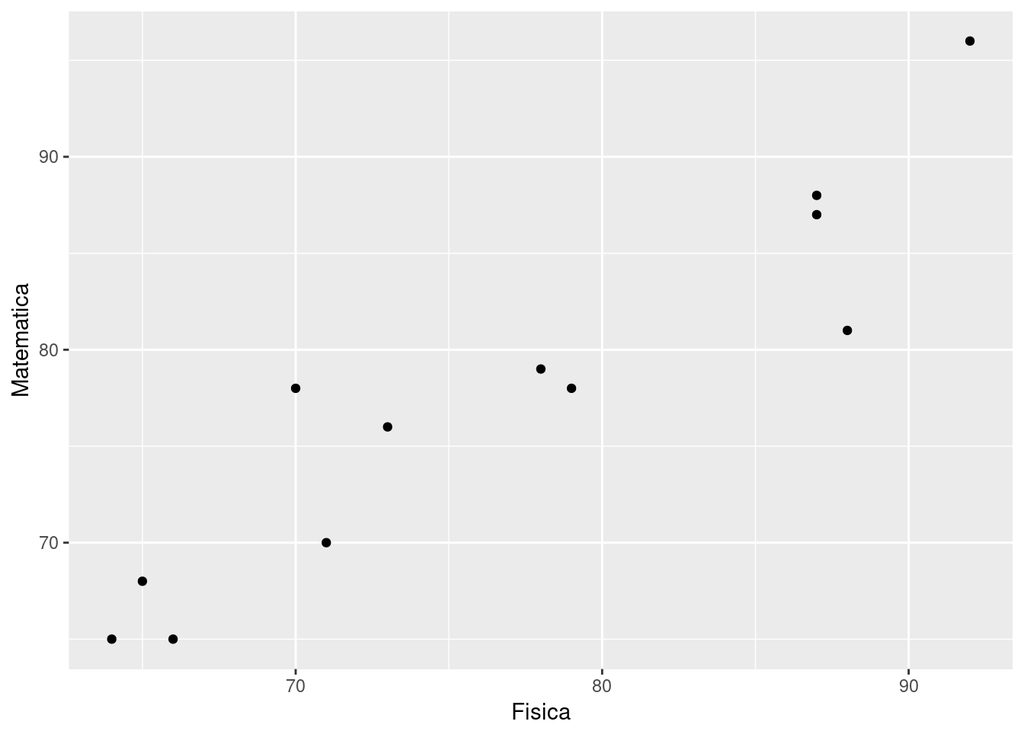

```r
library(ggplot2)
ggplot(x, aes(Fisica, Matematica)) +
  geom_point()
```

```r
with(x, cor(Fisica, Matematica))
```

```
[1] 0.932516
```

3. $$H_0: \rho = 0$$
   $$H_1: \rho \ne 0$$

```r
with(x, cor.test(Fisica, Matematica))
```

```
    Pearson's product-moment correlation

data:  Fisica and Matematica
t = 8.1657, df = 10, p-value = 9.835e-06
alternative hypothesis: true correlation is not equal to 0
95 percent confidence interval:
 0.7714998 0.9812693
sample estimates:
     cor
0.932516
```

Existen evidencias suficientes para rechazar $H_0$, la correlación es significativa (p<0.0001)

## Ejercicio 8

Con el objeto de indentificar variables asociadas con las diferencias de peso de semillas de trigo diploide (*Triticum monococcum*), Jing et al. (2007) estudiaron varios caracteres de (peso, longitud, diámetro, dureza) de 190 semillas obtenidas a azar. Los datos se encuentran en el archivo `semilla_trigo.xlsx`.

- ¿Existe asociación entre el peso y la longitud de la semilla? ¿Y entre el peso y la dureza del endosperma? Interprete el resultado de la prueba de hipótesis y la magnitud de la correlación obtenida.

  **Respuesta**

Asociación entre el peso y la longitud de la semilla:
$$H_0: \rho = 0$$
$$H_1: \rho \ne 0$$

```r
with(x, cor.test(Peso, Long))
```

```
    Pearson's product-moment correlation

data:  Peso and Long
t = 25.751, df = 188, p-value < 2.2e-16
alternative hypothesis: true correlation is not equal to 0
95 percent confidence interval:
 0.8467116 0.9106082
sample estimates:
      cor
0.8826743
```

Existen evidencias suficientes para rechazar $H_0$, la correlación entre Peso y Longitud de la semilla es significativa (p<0.0001) El coeficiente de correlación ($r$ 0.8826) indica que la correlación es positiva y alta entre las variables mencionadas. Es decir, a medida que aumenta la longitud de la semilla, aumenta el peso de la semilla.

Asociación entre el peso y la dureza del endosperma:
$$H_0: \rho = 0$$
$$H_1: \rho \ne 0$$

```r
with(x, cor.test(Peso, Dureza))
```

```
    Pearson's product-moment correlation

data:  Peso and Dureza
t = -2.9024, df = 188, p-value = 0.004146
alternative hypothesis: true correlation is not equal to 0
95 percent confidence interval:
 -0.33943682 -0.06670315
sample estimates:
       cor
-0.2070901
```

Existen evidencias suficientes para rechazar $H_0$, la correlación entre Peso y Dureza del endosperma es significativa (p=0.004) El coeficiente de correlación ($r$ -0.207) indica que la correlación es negativa y muy baja entre las variables mencionadas.

## Ejercicio 9

En un estudio sobre el éxito reproductivo de langostas, un entomólogo busca ajustar modelar la relación entre el peso de las hembras y el número de huevos que produce. Para ello selecciona 30 langostas de de diferentes pesos (en gramos) y registra el número de huevos que producen. Los datos se encuentran en el archivo `huevos.xlsx`

1. Grafique los datos
2. Calcule e interprete el coeficiente de correlación de estos datos.
3. ¿Qué proporción de variación del número de huevos explicaría el modelo lineal en función del peso de las langostas?

**Respuesta**

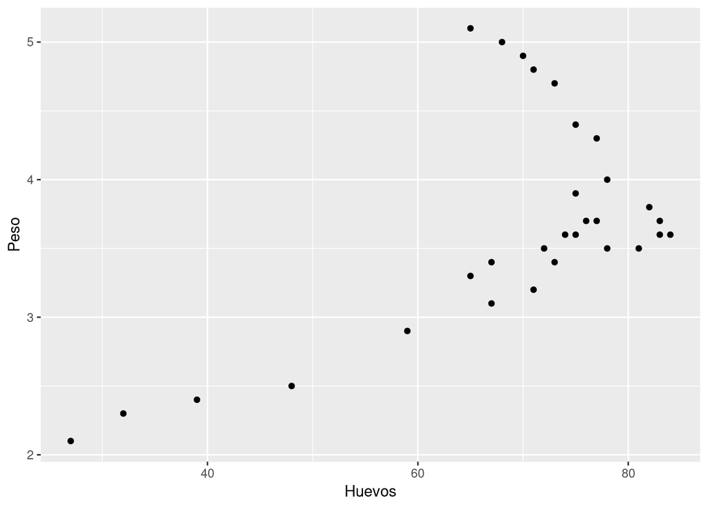

```r
library(ggplot2)
ggplot(x, aes(Huevos, Peso)) +
  geom_point()
```

```r
with(x, cor(Huevos,Peso))
```

```
[1] 0.6058657
```

El coeficiente de correlación de estos datos es $r$ = 0.6058, es un valor medio y positivo pero si lo comparamos con la grafica vemos que la relación entre las variables no es lineal.

```r
mod<- lm(Peso~ Huevos, x)
summary(mod)
```

```
Call:
lm(formula = Peso ~ Huevos, data = x)

Residuals:
     Min       1Q   Median       3Q      Max
-0.54722 -0.42485 -0.22177  0.05021  1.57515

Coefficients:
            Estimate Std. Error t value Pr(>|t|)
(Intercept) 1.402709   0.569450   2.463 0.020177 *
Huevos      0.032648   0.008102   4.030 0.000388 ***
---
Signif. codes:  0 '***' 0.001 '**' 0.01 '*' 0.05 '.' 0.1 ' ' 1

Residual standard error: 0.631 on 28 degrees of freedom
Multiple R-squared:  0.3671,    Adjusted R-squared:  0.3445
F-statistic: 16.24 on 1 and 28 DF,  p-value: 0.000388
```

La proporción de variación del número de huevos que explicaría el modelo lineal en función del peso de las langostas es de 36.71% ($R^2$)

## Ejercicio 10

Un investigador condujo un experimento para modelar la relación entre la ganancia de peso en pollos cuyas dietas fueron suplementadas con distintas cantidades de lisina (aminoácido) y la cantidad de lisina consumida. Dado que el porcentaje de lisina del alimento es conocido, la cantidad de lisina consumida se estima a partir de la cantidad de alimento consumida. Se seleccionó una muestra aleatoria de 12 pollos los cuales fueron alojados en jaulas individuales y alimintados a voluntad con el alimento más el suplemento.

```
# A tibble: 12 x 2
   ganancia lisina
      <dbl>  <dbl>
 1     14.7   0.09
 2     17.8   0.14
 3     19.6   0.18
 4     18.4   0.15
 5     20.5   0.16
 6     21.1   0.23
 7     17.2   0.11
 8     18.7   0.19
 9     20.2   0.23
10     16     0.13
11     17.8   0.17
12     19.4   0.21
```

`pollos.xlsx`

1. Grafique los datos
2. Estime los parámtros del modelo lineal.
3. ¿Qué proporción de la variación de la ganancia de peso es explicada por modelo en función de la lisina?
4. Si un pollo consumiera 0.20 g de lisina, ¿cual es el aumento de peso esperado? Estime con un 95% de confianza el intervalo de predicción para dicho aumento de peso.

**Respuesta**

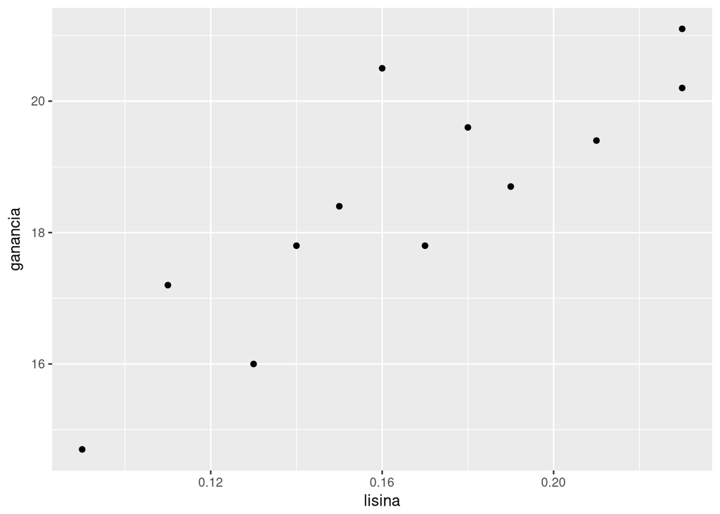

```r
library(ggplot2)
ggplot(x, aes(lisina, ganancia)) +
  geom_point()
```

```r
mod<- lm(ganancia~ lisina,x)
mod
```

```
Call:
lm(formula = ganancia ~ lisina, data = x)

Coefficients:
(Intercept)       lisina
      12.51        35.83
```

*$Y=12.51 + 35.83 X$* c.

```r
summary(mod)
```

```
Call:
lm(formula = ganancia ~ lisina, data = x)

Residuals:
    Min      1Q  Median      3Q     Max
-1.1662 -0.6741 -0.1367  0.5486  2.2590

Coefficients:
            Estimate Std. Error t value Pr(>|t|)
(Intercept)   12.509      1.192   10.50 1.02e-06 ***
lisina        35.828      6.957    5.15 0.000431 ***
---
Signif. codes:  0 '***' 0.001 '**' 0.01 '*' 0.05 '.' 0.1 ' ' 1

Residual standard error: 1.034 on 10 degrees of freedom
Multiple R-squared:  0.7262,    Adjusted R-squared:  0.6988
F-statistic: 26.52 on 1 and 10 DF,  p-value: 0.0004315
```

La proporción de la variación de la ganancia de peso es explicada por modelo en función de la lisina es de 72.62% ($R²$)

```r
predict(mod, newdata = list(lisina = 0.20), interval = "prediction", level = 0.95)
```

```
       fit     lwr      upr
1 19.67412 17.2183 22.12995
```

Si un pollo consumiera 0.20 g de lisina, el aumento de peso esperado sería 19.67 gramos. El intervalo de predicción (95% de confianza) para dicho aumento de peso es de 17.2183 a 22.1299 gramos.

## Ejercicio 11

Se desea probar la efectividad de un nuevo fungicida para el control de roya en trigo. Se probaron distintas dosis en gramos de principio activo por ha (gr.p.a./ha) en 13 parcelas de 100 plantas cada una. A los 15 días de la aplicación se realizó una evaluación del daño, como el tamaño promedio de las machas en hoja bandera.

```
# A tibble: 13 x 2
       X     Y
   <dbl> <dbl>
 1   100    50
 2   125    48
 3   150    45
 4   175    39
 5   200    35
 6   225    30
 7   250    27
 8   275    25
 9   300    20
10   325    17
11   350    12
12   375    10
13   400     5
```

`fungicida.xlsx`

1. Estime los parámetros del un modelo de regresión lineal.
2. Pruebe la significancia de la pendiente e interprete. Utilice $\alpha=0.05$. Calcule su intervalo de confianza del 95%.
3. Interprete la bondad de ajuste del modelo.
4. Estime e interprete el coeficiente que mide la relación entre las variables.
5. Predecir el daño (tamaño promedio de las manchas) que se hallará si se aplican 260 gr.p.a./ha

**Respuesta**

```r
mod<- lm(Y~ X, x)
mod
```

```
Call:
lm(formula = Y ~ X, data = x)

Coefficients:
(Intercept)            X
    66.0000      -0.1523
```

*$Y=66 - 0.1523 X$* b.

$$H_0: \beta_1 = 0$$
$$H_1: \beta_1 \ne 0$$

```r
summary(mod)
```

```
Call:
lm(formula = Y ~ X, data = x)

Residuals:
    Min      1Q  Median      3Q     Max
-1.7308 -0.6923 -0.3077  0.8846  1.8461

Coefficients:
             Estimate Std. Error t value Pr(>|t|)
(Intercept) 66.000000   0.833227   79.21  < 2e-16 ***
X           -0.152308   0.003122  -48.79 3.29e-14 ***
---
Signif. codes:  0 '***' 0.001 '**' 0.01 '*' 0.05 '.' 0.1 ' ' 1

Residual standard error: 1.053 on 11 degrees of freedom
Multiple R-squared:  0.9954,    Adjusted R-squared:  0.995
F-statistic:  2381 on 1 and 11 DF,  p-value: 3.289e-14
```

*Se rechaza $H_0$ (P<0.0001), la regresión es significativa*

```r
confint(mod)
```

```
                 2.5 %     97.5 %
(Intercept) 64.1660797 67.8339203
X           -0.1591782 -0.1454372
```

IC95% $\beta_1$ = -0.1591 ; -0.1454

3. La bondad de ajuste o $R²$ es 0.9954, es muy buen ajuste es decir que el 99.54% de la variación del tamaño promedio de las machas en hoja bandera es explicado por el modelo lineal en función de la dosis de fungicida.

```r
with(x, cor(X,Y))
```

```
[1] -0.9976977
```

El coeficiente de correlación de estos datos ($r$) es -0.9976, lo cual indica un relación inversa y alta entre las variables estudiadas, es decir que a medida que aumento la dosis de fungicida el tamaño promedio de manchas en la hoja bandera, disminuye.

```r
predict(mod, newdata = list(X = 260))
```

```
   1
26.4
```

El daño (tamaño promedio de las manchas) que se hallará si se aplican 260 gr.p.a./ha es de 26.4.

## Ejercicio 12

Los datos se refieren al contenido de proteína bruta (PB) y caseína (CA) en leche en una muestra de 23 tambos de la cuenca lechera del centro del país.

```
# A tibble: 23 x 2
      PB    CA
   <dbl> <dbl>
 1  2.74  1.87
 2  3.19  2.26
 3  2.96  2.07
 4  2.91  2.09
 5  3.23  2.28
 6  3.04  2.04
 7  3.08  2.18
 8  3.23  2.3
 9  3.11  2.17
10  3.11  2.15
# ... with 13 more rows
```

`proteina_caseina.xlsx`

Indique y pruebe la significancia de la relación entre las variables. Utilice $\alpha=0.05$.

**Respuesta**

$$H_0: \rho = 0$$
$$H_1: \rho \ne 0$$

```r
with(x, cor.test(PB,CA))
```

```
    Pearson's product-moment correlation

data:  PB and CA
t = 12.022, df = 21, p-value = 7.045e-11
alternative hypothesis: true correlation is not equal to 0
95 percent confidence interval:
 0.8493513 0.9721675
sample estimates:
      cor
0.9344118
```

Existen evidencias suficientes para rechazar la $H_0$ (p<0.0001) por lo que la correlación lineal entre la proteina bruta y la caseina de la leche es significativa. Además el coeficiente de correlación de estas variables ($r$ = 0.9344) es alto y positivo, es decir que cuando encontramos alto contenido de proteína bruta tambien encontraremos alto contenido de caseina en la leche.